# A Guide to Proper Scoring

2025-07-09

## Introduction

When evaluating machine learning models, the choice of evaluation metric can significantly impact which model appears “best.” This document demonstrates why different scoring metrics are appropriate for different types of predictions and how proper scoring rules help us make better choices.

## Setup and Data Generation

```r
library(dplyr)
library(scoringutils)
library(scoringRules)

# Set seed for reproducibility
set.seed(42)
```

Let’s create a synthetic dataset that mimics real-world wage prediction scenarios:

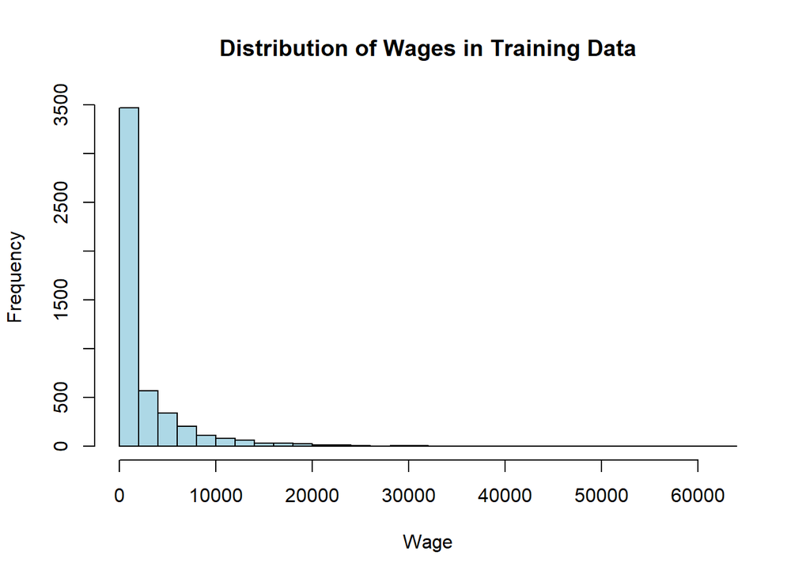

```r
# Create synthetic wage data for 5000 individuals
n <- 5000

# Generate age between 20 and 60
age <- round(runif(n, min = 20, max = 60))

# Define education levels and their probabilities
education_levels <- c("High School", "Bachelor's", "Master's")
education_probs <- c(0.4, 0.4, 0.2)
education <- sample(education_levels, n, replace = TRUE, prob = education_probs)

# Simulate experience correlated with age (with some noise)
experience <- age - 20 + round(rnorm(n, mean = 0, sd = 3))

# Generate wages using a non-linear function
wage <- exp((age * 0.1) +
            (case_when(education == "High School" ~ 1,
                       education == "Bachelor's" ~ 1.5,
                       TRUE ~ 2)) +
            (experience * 0.05) +
            rnorm(n, mean = 0, sd = 0.5))

# Visualize the wage distribution
hist(wage, main = "Distribution of Wages in Training Data",
     xlab = "Wage", col = "lightblue", breaks = 30)
```

## Example: Predicting Dave’s Wage

Let’s examine predictions for a specific individual - Dave:

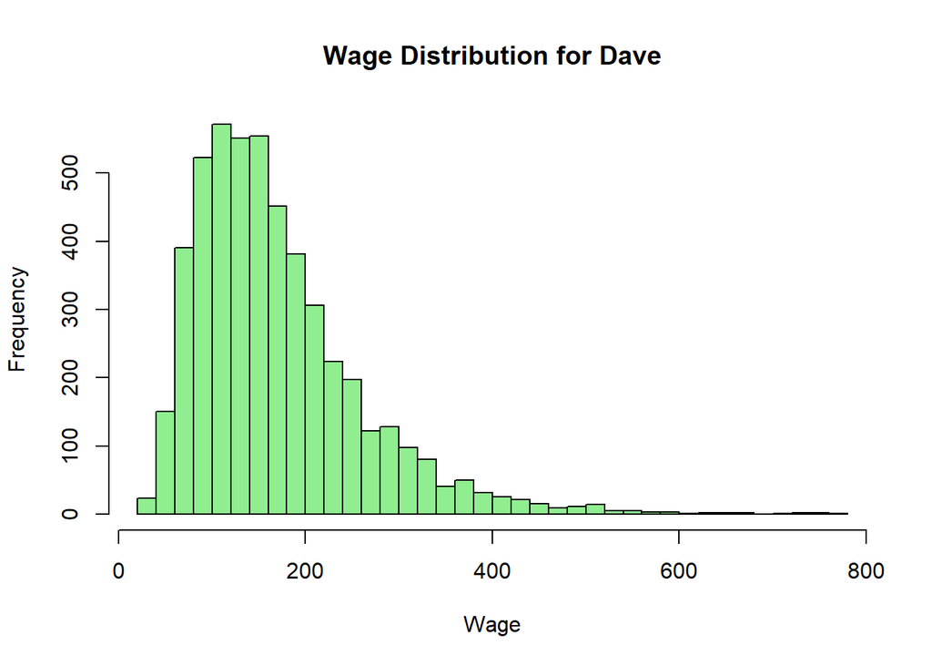

```r
# Dave's characteristics
ageDave <- 30
educationDave <- "Bachelor's"
experienceDave <- 10

# Generate Dave's wage distribution (what we're trying to predict)
wageDave <- exp((ageDave * 0.1) +
                (case_when(educationDave == "High School" ~ 1,
                           educationDave == "Bachelor's" ~ 1.5,
                           TRUE ~ 2)) +
                (experienceDave * 0.05) +
                rnorm(n, mean = 0, sd = 0.5))

hist(wageDave, main = "Wage Distribution for Dave",
     xlab = "Wage", col = "lightgreen", breaks = 30)
```

## Test Set Generation

```r
# Generate test set of 1000 individuals
ntest <- 1000

agetest <- round(runif(ntest, min = 20, max = 60))
educationtest <- sample(education_levels, ntest, replace = TRUE, prob = education_probs)
experiencetest <- agetest - 20 + round(rnorm(ntest, mean = 0, sd = 3))

# True wages for test set (what we're trying to predict)
wagetest <- exp((agetest * 0.1) +
                (case_when(educationtest == "High School" ~ 1,
                           educationtest == "Bachelor's" ~ 1.5,
                           TRUE ~ 2)) +
                (experiencetest * 0.05) +
                rnorm(ntest, mean = 0, sd = 0.5))

# Create test data frame
Xtest <- data.frame(age = agetest, education = educationtest, experience = experiencetest)
```

## Point Predictions: Mean vs Median

### Defining Our Estimators

```r
# Function to estimate conditional mean
conditionalmeanest <- function(age, education, experience, N = 1000) {
  mean(exp((age * 0.1) +
           (case_when(education == "High School" ~ 1,
                      education == "Bachelor's" ~ 1.5,
                      TRUE ~ 2)) +
           (experience * 0.05) +
           rnorm(N, mean = 0, sd = 0.5)))
}

# Function to estimate conditional median
conditionalmedianest <- function(age, education, experience, N = 1000) {
  median(exp((age * 0.1) +
             (case_when(education == "High School" ~ 1,
                        education == "Bachelor's" ~ 1.5,
                        TRUE ~ 2)) +
             (experience * 0.05) +
             rnorm(N, mean = 0, sd = 0.5)))
}
```

### Visualizing Mean vs Median for Dave

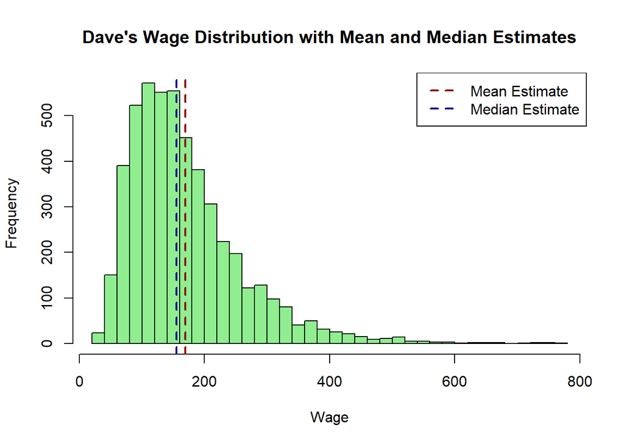

```r
# Calculate mean and median estimates for Dave
dave_mean <- conditionalmeanest(ageDave, educationDave, experienceDave)
dave_median <- conditionalmedianest(ageDave, educationDave, experienceDave)

# Plot Dave's wage distribution with mean and median
hist(wageDave, main = "Dave's Wage Distribution with Mean and Median Estimates",
     xlab = "Wage", col = "lightgreen", breaks = 30)
abline(v = dave_mean, col = "darkred", lwd = 2, lty = 2)
abline(v = dave_median, col = "darkblue", lwd = 2, lty = 2)
legend("topright", legend = c("Mean Estimate", "Median Estimate"),
       col = c("darkred", "darkblue"), lwd = 2, lty = 2)
```

### Comparing MSE and MAE

```r
# Generate predictions for test set
meanest <- sapply(1:nrow(Xtest), function(j)
  conditionalmeanest(Xtest$age[j], Xtest$education[j], Xtest$experience[j]))

medianest <- sapply(1:nrow(Xtest), function(j)
  conditionalmedianest(Xtest$age[j], Xtest$education[j], Xtest$experience[j]))

# Calculate Mean Squared Error (MSE)
MSE1 <- mean((meanest - wagetest)^2)
MSE2 <- mean((medianest - wagetest)^2)

# Calculate Mean Absolute Error (MAE)
MAE1 <- mean(abs(meanest - wagetest))
MAE2 <- mean(abs(medianest - wagetest))

# Results
cat("MSE Results:\n")
```

```
## MSE Results:
```

```r
cat("Mean Estimator MSE:", round(MSE1, 2), "\n")
```

```
## Mean Estimator MSE: 4705325
```

```r
cat("Median Estimator MSE:", round(MSE2, 2), "\n")
```

```
## Median Estimator MSE: 5106329
```

```r
cat("Mean estimator is better for MSE:", MSE1 < MSE2, "\n\n")
```

```
## Mean estimator is better for MSE: TRUE
```

```r
cat("MAE Results:\n")
```

```
## MAE Results:
```

```r
cat("Mean Estimator MAE:", round(MAE1, 2), "\n")
```

```
## Mean Estimator MAE: 847.42
```

```r
cat("Median Estimator MAE:", round(MAE2, 2), "\n")
```

```
## Median Estimator MAE: 816.24
```

```r
cat("Median estimator is better for MAE:", MAE2 < MAE1, "\n")
```

```
## Median estimator is better for MAE: TRUE
```

**Key Insight**: The mean estimator minimizes MSE, while the median estimator minimizes MAE. This demonstrates why the choice of metric matters!

## Interval Predictions: Quantile Scoring

### Defining Quantile Estimators

```r
# Function to estimate conditional quantiles
conditionalquantileest <- function(probs, age, education, experience, N = 1000) {
  quantile(exp((age * 0.1) +
               (case_when(education == "High School" ~ 1,
                          education == "Bachelor's" ~ 1.5,
                          TRUE ~ 2)) +
               (experience * 0.05) +
               rnorm(N, mean = 0, sd = 0.5)),
           probs = probs)
}

# Naive estimator bounds
lowernaive <- 0
uppernaive <- max(wage)

# Confidence level
alpha <- 0.05  # 95% confidence interval
```

### Calculating Interval Scores

```r
# Calculate proper quantile estimates
lower <- sapply(1:nrow(Xtest), function(j)
  conditionalquantileest(alpha/2, Xtest$age[j], Xtest$education[j], Xtest$experience[j]))

upper <- sapply(1:nrow(Xtest), function(j)
  conditionalquantileest(1 - alpha/2, Xtest$age[j], Xtest$education[j], Xtest$experience[j]))

# Calculate quantile scores
qs_lower <- mean(quantile_score(wagetest, predicted = as.matrix(lower), quantile_level = alpha/2))
qs_upper <- mean(quantile_score(wagetest, predicted = as.matrix(upper), quantile_level = 1 - alpha/2))

# Calculate quantile scores for naive estimator
qs_lowernaive <- mean(quantile_score(wagetest, predicted = as.matrix(rep(lowernaive, ntest)), quantile_level = alpha/2))
qs_uppernaive <- mean(quantile_score(wagetest, predicted = as.matrix(rep(uppernaive, ntest)), quantile_level = 1 - alpha/2))

# Calculate interval scores
interval_score <- (qs_lower + qs_upper) / 2
interval_scorenaive <- (qs_lowernaive + qs_uppernaive) / 2

cat("Interval Scoring Results:\n")
```

```
## Interval Scoring Results:
```

```r
cat("Proper Estimator Score:", round(interval_score, 2), "\n")
```

```
## Proper Estimator Score: 138.97
```

```r
cat("Naive Estimator Score:", round(interval_scorenaive, 2), "\n")
```

```
## Naive Estimator Score: 1573.67
```

```r
cat("Improvement ratio:", round(interval_scorenaive / interval_score, 2), "x better\n")
```

```
## Improvement ratio: 11.32 x better
```

## Distributional Predictions: Energy Score

### Defining Distribution Estimators

```r
# Proper distribution estimator: samples from true conditional distribution
distributionestimate <- function(age, education, experience, N = 100) {
  exp((age * 0.1) +
      (case_when(education == "High School" ~ 1,
                 education == "Bachelor's" ~ 1.5,
                 TRUE ~ 2)) +
      (experience * 0.05) +
      rnorm(N, mean = 0, sd = 0.5))
}

# Naive distribution estimator: ignores individual characteristics
distributionestimatenaive <- function(age, education, experience, N = 100) {
  exp(rnorm(N, mean = 0, sd = 0.5))
}
```

### Calculating Energy Scores

```r
# Calculate energy scores for proper estimator
scoretrue <- mean(sapply(1:nrow(Xtest), function(j) {
  wageest <- distributionestimate(Xtest$age[j], Xtest$education[j], Xtest$experience[j])
  return(scoringRules::es_sample(y = wagetest[j], dat = matrix(wageest, nrow = 1)))
}))

# Calculate energy scores for naive estimator
scorenaive <- mean(sapply(1:nrow(Xtest), function(j) {
  wageest <- distributionestimatenaive(Xtest$age[j], Xtest$education[j], Xtest$experience[j])
  return(scoringRules::es_sample(y = wagetest[j], dat = matrix(wageest, nrow = 1)))
}))

cat("Energy Score Results:\n")
```

```
## Energy Score Results:
```

```r
cat("Proper Distribution Estimator:", round(scoretrue, 2), "\n")
```

```
## Proper Distribution Estimator: 589.35
```

```r
cat("Naive Distribution Estimator:", round(scorenaive, 2), "\n")
```

```
## Naive Distribution Estimator: 2297.29
```

```r
cat("Improvement ratio:", round(scorenaive / scoretrue, 2), "x better\n")
```

```
## Improvement ratio: 3.9 x better
```

## Summary of Results

```r
# Create a summary table
results_summary <- data.frame(
  Metric = c("MSE", "MAE", "Interval Score", "Energy Score"),
  `Best Estimator` = c("Mean", "Median", "Proper Quantiles", "Proper Distribution"),
  `Proper Score` = c(round(MSE1, 2), round(MAE2, 2), round(interval_score, 2), round(scoretrue, 2)),
  `Naive Score` = c(round(MSE2, 2), round(MAE1, 2), round(interval_scorenaive, 2), round(scorenaive, 2)),
  `Improvement` = c(paste0(round(MSE2/MSE1, 2), "x"),
                    paste0(round(MAE1/MAE2, 2), "x"),
                    paste0(round(interval_scorenaive/interval_score, 2), "x"),
                    paste0(round(scorenaive/scoretrue, 2), "x")),
  check.names = FALSE
)

print(results_summary)
```

```
##           Metric      Best Estimator Proper Score Naive Score Improvement
## 1            MSE                Mean   4705324.51  5106328.79       1.09x
## 2            MAE              Median       816.24      847.42       1.04x
## 3 Interval Score    Proper Quantiles       138.97     1573.67      11.32x
## 4   Energy Score Proper Distribution       589.35     2297.29        3.9x
```

## Key Takeaways

1. **Proper Scoring Rules**: Different metrics are “proper” for different types of predictions:
   - **MSE** is proper for mean predictions
   - **MAE** is proper for median predictions
   - **Quantile Score** is proper for quantile predictions
   - **Energy Score** is proper for distributional predictions
2. **Metric Choice Matters**: The “best” model depends entirely on your evaluation metric. A model that excels at MSE might perform poorly on MAE.
3. **Match Your Metric to Your Goal**:
   - Use MSE when you care about mean predictions
   - Use MAE when you care about median predictions
   - Use interval scores for uncertainty quantification
   - Use energy scores for full distributional predictions
4. **Avoid Metric Misalignment**: Don’t optimize for one metric while evaluating with another, as this can lead to suboptimal model selection.

This framework helps ensure that your model evaluation aligns with your actual prediction goals, leading to better model selection and deployment decisions.